# Table of Contents

# Data Preparation for Modelling

## Correlation

```python
# bp.show_methods(bp, contains='corr') # my local functions
```

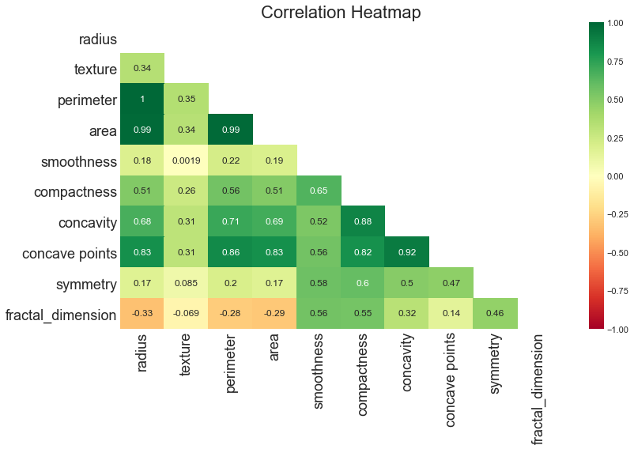

```python
# select only the mean features
cols = df_train.filter(regex='_mean').columns.tolist()
df1 = df_train[cols].rename(columns=lambda x: x.replace('_mean',''))

bp.plot_corr(df1,xrot=90)
```

```python
bp.plot_corr_style(df_train)
```

Hover to magify

|  | diagnosis | radius_mean | texture_mean | perimeter_mean | area_mean | smoothness_mean | compactness_mean | concavity_mean | concave points_mean | symmetry_mean | fractal_dimension_mean | radius_se | texture_se | perimeter_se | area_se | smoothness_se | compactness_se | concavity_se | concave points_se | symmetry_se | fractal_dimension_se | radius_worst | texture_worst | perimeter_worst | area_worst | smoothness_worst | compactness_worst | concavity_worst | concave points_worst | … |
| --- | --- | --- | --- | --- | --- | --- | --- | --- | --- | --- | --- | --- | --- | --- | --- | --- | --- | --- | --- | --- | --- | --- | --- | --- | --- | --- | --- | --- | --- | --- |
| diagnosis | 1.00 | 0.73 | 0.43 | 0.75 | 0.71 | 0.37 | 0.61 | 0.69 | 0.78 | 0.34 | -0.03 | 0.57 | 0.02 | 0.56 | 0.54 | -0.05 | 0.29 | 0.23 | 0.41 | -0.03 | 0.07 | 0.78 | 0.47 | 0.79 | 0.74 | 0.42 | 0.58 | 0.65 | 0.79 | … |
| radius_mean | 0.73 | 1.00 | 0.34 | 1.00 | 0.99 | 0.18 | 0.51 | 0.68 | 0.83 | 0.17 | -0.33 | 0.69 | -0.06 | 0.68 | 0.73 | -0.20 | 0.20 | 0.18 | 0.38 | -0.11 | -0.05 | 0.97 | 0.31 | 0.96 | 0.94 | 0.11 | 0.39 | 0.52 | 0.74 | … |
| texture_mean | 0.43 | 0.34 | 1.00 | 0.35 | 0.34 | 0.00 | 0.26 | 0.31 | 0.31 | 0.08 | -0.07 | 0.26 | 0.36 | 0.27 | 0.26 | -0.00 | 0.20 | 0.14 | 0.19 | -0.01 | 0.05 | 0.37 | 0.91 | 0.37 | 0.36 | 0.11 | 0.29 | 0.32 | 0.32 | … |
| perimeter_mean | 0.75 | 1.00 | 0.35 | 1.00 | 0.99 | 0.22 | 0.56 | 0.71 | 0.86 | 0.20 | -0.28 | 0.70 | -0.05 | 0.70 | 0.74 | -0.18 | 0.25 | 0.21 | 0.41 | -0.09 | -0.01 | 0.97 | 0.31 | 0.97 | 0.94 | 0.14 | 0.43 | 0.55 | 0.77 | … |
| area_mean | 0.71 | 0.99 | 0.34 | 0.99 | 1.00 | 0.19 | 0.51 | 0.69 | 0.83 | 0.17 | -0.29 | 0.74 | -0.03 | 0.74 | 0.80 | -0.14 | 0.21 | 0.19 | 0.38 | -0.08 | -0.02 | 0.96 | 0.29 | 0.96 | 0.96 | 0.12 | 0.37 | 0.50 | 0.72 | … |
| smoothness_mean | 0.37 | 0.18 | 0.00 | 0.22 | 0.19 | 1.00 | 0.65 | 0.52 | 0.56 | 0.58 | 0.56 | 0.30 | 0.10 | 0.30 | 0.25 | 0.33 | 0.31 | 0.24 | 0.37 | 0.18 | 0.27 | 0.22 | 0.06 | 0.25 | 0.22 | 0.79 | 0.46 | 0.44 | 0.51 | … |
| compactness_mean | 0.61 | 0.51 | 0.26 | 0.56 | 0.51 | 0.65 | 1.00 | 0.88 | 0.82 | 0.60 | 0.55 | 0.49 | 0.07 | 0.53 | 0.45 | 0.14 | 0.75 | 0.55 | 0.63 | 0.20 | 0.51 | 0.54 | 0.26 | 0.59 | 0.52 | 0.56 | 0.87 | 0.82 | 0.82 | … |
| concavity_mean | 0.69 | 0.68 | 0.31 | 0.71 | 0.69 | 0.52 | 0.88 | 1.00 | 0.92 | 0.50 | 0.32 | 0.63 | 0.11 | 0.65 | 0.61 | 0.11 | 0.67 | 0.69 | 0.68 | 0.16 | 0.45 | 0.68 | 0.30 | 0.72 | 0.67 | 0.43 | 0.73 | 0.88 | 0.85 | … |
| concave points_mean | 0.78 | 0.83 | 0.31 | 0.86 | 0.83 | 0.56 | 0.82 | 0.92 | 1.00 | 0.47 | 0.14 | 0.70 | 0.06 | 0.71 | 0.69 | 0.04 | 0.48 | 0.42 | 0.60 | 0.08 | 0.25 | 0.83 | 0.30 | 0.86 | 0.81 | 0.44 | 0.64 | 0.74 | 0.91 | … |
| symmetry_mean | 0.34 | 0.17 | 0.08 | 0.20 | 0.17 | 0.58 | 0.60 | 0.50 | 0.47 | 1.00 | 0.46 | 0.30 | 0.12 | 0.30 | 0.22 | 0.15 | 0.39 | 0.32 | 0.36 | 0.39 | 0.31 | 0.21 | 0.09 | 0.24 | 0.20 | 0.44 | 0.47 | 0.44 | 0.45 | … |
| fractal_dimension_mean | -0.03 | -0.33 | -0.07 | -0.28 | -0.29 | 0.56 | 0.55 | 0.32 | 0.14 | 0.46 | 1.00 | -0.03 | 0.18 | 0.01 | -0.11 | 0.40 | 0.56 | 0.44 | 0.33 | 0.33 | 0.69 | -0.27 | -0.05 | -0.23 | -0.24 | 0.49 | 0.45 | 0.34 | 0.16 | … |
| radius_se | 0.57 | 0.69 | 0.26 | 0.70 | 0.74 | 0.30 | 0.49 | 0.63 | 0.70 | 0.30 | -0.03 | 1.00 | 0.22 | 0.97 | 0.95 | 0.17 | 0.34 | 0.32 | 0.51 | 0.24 | 0.21 | 0.72 | 0.17 | 0.72 | 0.75 | 0.12 | 0.26 | 0.37 | 0.53 | … |
| texture_se | 0.02 | -0.06 | 0.36 | -0.05 | -0.03 | 0.10 | 0.07 | 0.11 | 0.06 | 0.12 | 0.18 | 0.22 | 1.00 | 0.23 | 0.12 | 0.36 | 0.25 | 0.22 | 0.28 | 0.44 | 0.30 | -0.08 | 0.38 | -0.07 | -0.06 | -0.08 | -0.08 | -0.05 | -0.08 | … |
| perimeter_se | 0.56 | 0.68 | 0.27 | 0.70 | 0.74 | 0.30 | 0.53 | 0.65 | 0.71 | 0.30 | 0.01 | 0.97 | 0.23 | 1.00 | 0.94 | 0.15 | 0.40 | 0.34 | 0.55 | 0.26 | 0.23 | 0.70 | 0.18 | 0.72 | 0.73 | 0.11 | 0.31 | 0.40 | 0.55 | … |
| area_se | 0.54 | 0.73 | 0.26 | 0.74 | 0.80 | 0.25 | 0.45 | 0.61 | 0.69 | 0.22 | -0.11 | 0.95 | 0.12 | 0.94 | 1.00 | 0.08 | 0.27 | 0.25 | 0.41 | 0.13 | 0.12 | 0.75 | 0.18 | 0.75 | 0.81 | 0.11 | 0.26 | 0.37 | 0.53 | … |
| smoothness_se | -0.05 | -0.20 | -0.00 | -0.18 | -0.14 | 0.33 | 0.14 | 0.11 | 0.04 | 0.15 | 0.40 | 0.17 | 0.36 | 0.15 | 0.08 | 1.00 | 0.34 | 0.27 | 0.33 | 0.42 | 0.44 | -0.21 | -0.09 | -0.20 | -0.17 | 0.30 | -0.05 | -0.05 | -0.09 | … |
| compactness_se | 0.29 | 0.20 | 0.20 | 0.25 | 0.21 | 0.31 | 0.75 | 0.67 | 0.48 | 0.39 | 0.56 | 0.34 | 0.25 | 0.40 | 0.27 | 0.34 | 1.00 | 0.79 | 0.73 | 0.40 | 0.81 | 0.20 | 0.14 | 0.25 | 0.19 | 0.22 | 0.68 | 0.65 | 0.48 | … |
| concavity_se | 0.23 | 0.18 | 0.14 | 0.21 | 0.19 | 0.24 | 0.55 | 0.69 | 0.42 | 0.32 | 0.44 | 0.32 | 0.22 | 0.34 | 0.25 | 0.27 | 0.79 | 1.00 | 0.77 | 0.30 | 0.73 | 0.17 | 0.09 | 0.20 | 0.17 | 0.14 | 0.45 | 0.66 | 0.42 | … |
| concave points_se | 0.41 | 0.38 | 0.19 | 0.41 | 0.38 | 0.37 | 0.63 | 0.68 | 0.60 | 0.36 | 0.33 | 0.51 | 0.28 | 0.55 | 0.41 | 0.33 | 0.73 | 0.77 | 1.00 | 0.30 | 0.62 | 0.36 | 0.10 | 0.39 | 0.34 | 0.19 | 0.43 | 0.55 | 0.59 | … |
| symmetry_se | -0.03 | -0.11 | -0.01 | -0.09 | -0.08 | 0.18 | 0.20 | 0.16 | 0.08 | 0.39 | 0.33 | 0.24 | 0.44 | 0.26 | 0.13 | 0.42 | 0.40 | 0.30 | 0.30 | 1.00 | 0.38 | -0.14 | -0.12 | -0.12 | -0.12 | -0.04 | 0.03 | 0.01 | -0.05 | … |
| fractal_dimension_se | 0.07 | -0.05 | 0.05 | -0.01 | -0.02 | 0.27 | 0.51 | 0.45 | 0.25 | 0.31 | 0.69 | 0.21 | 0.30 | 0.23 | 0.12 | 0.44 | 0.81 | 0.73 | 0.62 | 0.38 | 1.00 | -0.05 | -0.01 | -0.01 | -0.03 | 0.15 | 0.38 | 0.38 | 0.21 | … |
| radius_worst | 0.78 | 0.97 | 0.37 | 0.97 | 0.96 | 0.22 | 0.54 | 0.68 | 0.83 | 0.21 | -0.27 | 0.72 | -0.08 | 0.70 | 0.75 | -0.21 | 0.20 | 0.17 | 0.36 | -0.14 | -0.05 | 1.00 | 0.37 | 0.99 | 0.98 | 0.22 | 0.46 | 0.56 | 0.79 | … |
| texture_worst | 0.47 | 0.31 | 0.91 | 0.31 | 0.29 | 0.06 | 0.26 | 0.30 | 0.30 | 0.09 | -0.05 | 0.17 | 0.38 | 0.18 | 0.18 | -0.09 | 0.14 | 0.09 | 0.10 | -0.12 | -0.01 | 0.37 | 1.00 | 0.38 | 0.36 | 0.26 | 0.38 | 0.38 | 0.38 | … |
| perimeter_worst | 0.79 | 0.96 | 0.37 | 0.97 | 0.96 | 0.25 | 0.59 | 0.72 | 0.86 | 0.24 | -0.23 | 0.72 | -0.07 | 0.72 | 0.75 | -0.20 | 0.25 | 0.20 | 0.39 | -0.12 | -0.01 | 0.99 | 0.38 | 1.00 | 0.98 | 0.23 | 0.51 | 0.60 | 0.81 | … |
| area_worst | 0.74 | 0.94 | 0.36 | 0.94 | 0.96 | 0.22 | 0.52 | 0.67 | 0.81 | 0.20 | -0.24 | 0.75 | -0.06 | 0.73 | 0.81 | -0.17 | 0.19 | 0.17 | 0.34 | -0.12 | -0.03 | 0.98 | 0.36 | 0.98 | 1.00 | 0.21 | 0.42 | 0.53 | 0.75 | … |
| smoothness_worst | 0.42 | 0.11 | 0.11 | 0.14 | 0.12 | 0.79 | 0.56 | 0.43 | 0.44 | 0.44 | 0.49 | 0.12 | -0.08 | 0.11 | 0.11 | 0.30 | 0.22 | 0.14 | 0.19 | -0.04 | 0.15 | 0.22 | 0.26 | 0.23 | 0.21 | 1.00 | 0.57 | 0.52 | 0.55 | … |
| compactness_worst | 0.58 | 0.39 | 0.29 | 0.43 | 0.37 | 0.46 | 0.87 | 0.73 | 0.64 | 0.47 | 0.45 | 0.26 | -0.08 | 0.31 | 0.26 | -0.05 | 0.68 | 0.45 | 0.43 | 0.03 | 0.38 | 0.46 | 0.38 | 0.51 | 0.42 | 0.57 | 1.00 | 0.88 | 0.79 | … |
| concavity_worst | 0.65 | 0.52 | 0.32 | 0.55 | 0.50 | 0.44 | 0.82 | 0.88 | 0.74 | 0.44 | 0.34 | 0.37 | -0.05 | 0.40 | 0.37 | -0.05 | 0.65 | 0.66 | 0.55 | 0.01 | 0.38 | 0.56 | 0.38 | 0.60 | 0.53 | 0.52 | 0.88 | 1.00 | 0.85 | … |
| concave points_worst | 0.79 | 0.74 | 0.32 | 0.77 | 0.72 | 0.51 | 0.82 | 0.85 | 0.91 | 0.45 | 0.16 | 0.53 | -0.08 | 0.55 | 0.53 | -0.09 | 0.48 | 0.42 | 0.59 | -0.05 | 0.21 | 0.79 | 0.38 | 0.81 | 0.75 | 0.55 | 0.79 | 0.85 | 1.00 | … |
| symmetry_worst | 0.39 | 0.14 | 0.11 | 0.16 | 0.12 | 0.39 | 0.49 | 0.37 | 0.34 | 0.68 | 0.31 | 0.06 | -0.15 | 0.07 | 0.04 | -0.13 | 0.25 | 0.15 | 0.09 | 0.31 | 0.08 | 0.23 | 0.25 | 0.25 | 0.19 | 0.52 | 0.61 | 0.51 | 0.49 | … |
| fractal_dimension_worst | 0.31 | -0.02 | 0.13 | 0.03 | -0.02 | 0.49 | 0.70 | 0.50 | 0.35 | 0.43 | 0.77 | 0.02 | -0.03 | 0.06 | -0.01 | 0.11 | 0.60 | 0.42 | 0.30 | 0.07 | 0.58 | 0.07 | 0.23 | 0.12 | 0.06 | 0.62 | 0.81 | 0.68 | 0.50 | … |

```python
bp.get_high_correlated_features_df(df_train).head()
```

|  | feature1 | feature2 | corr |
| --- | --- | --- | --- |
| 31 | radius_mean | perimeter_mean | 0.998112 |
| 33 | radius_worst | perimeter_worst | 0.994136 |
| 35 | radius_mean | area_mean | 0.987089 |
| 37 | perimeter_mean | area_mean | 0.986662 |
| 39 | radius_worst | area_worst | 0.983782 |

```python
# bp.show_methods(df_train.bp)
```

```python
df_train.bp.corr_high(thr=0.98)
```

```
cols_high_corr = ['area_mean', 'radius_worst', 'radius_mean', 'area_worst', 'perimeter_worst', 'perimeter_mean']
cols_high_corr1 = ['radius_mean', 'radius_worst', 'radius_mean', 'perimeter_mean', 'radius_worst']
cols_high_corr2 = ['perimeter_mean', 'perimeter_worst', 'area_mean', 'area_mean', 'area_worst']
cols_high_corr_drop = ['radius_mean', 'radius_worst']
```

|  | feature1 | feature2 | corr |
| --- | --- | --- | --- |
| 0 | radius_mean | perimeter_mean | 0.998112 |
| 1 | radius_worst | perimeter_worst | 0.994136 |
| 2 | radius_mean | area_mean | 0.987089 |
| 3 | perimeter_mean | area_mean | 0.986662 |
| 4 | radius_worst | area_worst | 0.983782 |

```python
cols_high_corr_drop = ['area_worst', 'perimeter_mean', 'perimeter_se']
df_train2 = df_train.drop(cols_high_corr_drop,axis=1)
df_test2  = df_test.drop(cols_high_corr_drop,axis=1)
```

# Modelling: Boosting Xgboost

```python
import xgboost as xgb
import sklearn.metrics as skmetrics

def get_row_eval(model,desc,df_eval,sort='F1'):
    model.fit(df_Xtrain, ser_ytrain)
    ypreds = model.predict(df_Xtest)
    ytx = np.array(ser_ytest).flatten()
    average = 'binary'
    row_eval = ['Xgboost',desc,
                skmetrics.accuracy_score(ytx, ypreds),
                skmetrics.precision_score(ytx, ypreds, average=average),
                skmetrics.recall_score(ytx, ypreds, average=average),
                skmetrics.f1_score(ytx, ypreds, average=average),
                skmetrics.roc_auc_score(ytx, ypreds)]

    return row_eval,ypreds
```

## default xgboost

```python
df_Xtrain = df_train.drop(target,axis=1)
ser_ytrain = df_train[target]
df_Xtest = df_test.drop(target,axis=1)
ser_ytest = df_test[target]


model = xgb.XGBClassifier(n_jobs=-1, random_state=SEED)
row_eval,ypreds = get_row_eval(model,'default',df_eval)
df_eval.loc[len(df_eval)] = row_eval
df_eval = df_eval.drop_duplicates(subset=['Model','Description'])
df_eval = df_eval.sort_values('F1',ascending=False)
display(df_eval)
```

|  | Model | Description | Accuracy | Precision | Recall | F1 | AUC |
| --- | --- | --- | --- | --- | --- | --- | --- |
| 0 | Xgboost | default | 0.973684 | 0.97561 | 0.952381 | 0.963855 | 0.969246 |

## Remove correlated features

```python
df_Xtrain = df_train2.drop(target,axis=1)
ser_ytrain = df_train2[target]
df_Xtest = df_test2.drop(target,axis=1)
ser_ytest = df_test2[target]


# fitting
model = xgb.XGBClassifier(n_jobs=-1, random_state=SEED)
row_eval,ypreds = get_row_eval(model,'corr_thr<0.98',df_eval)
df_eval.loc[len(df_eval)] = row_eval
df_eval = df_eval.drop_duplicates(subset=['Model','Description'])
df_eval = df_eval.sort_values('F1',ascending=False)
display(df_eval)

# removing correlated features gave worse result.
```

|  | Model | Description | Accuracy | Precision | Recall | F1 | AUC |
| --- | --- | --- | --- | --- | --- | --- | --- |
| 0 | Xgboost | default | 0.973684 | 0.97561 | 0.952381 | 0.963855 | 0.969246 |
| 1 | Xgboost | corr_thr<0.98 | 0.964912 | 0.97500 | 0.928571 | 0.951220 | 0.957341 |

## Recursive Feature Elimination

```python
from sklearn.feature_selection import RFECV

model = xgb.XGBClassifier(n_jobs=-1, random_state=SEED)
est = RFECV(model,step=1,cv=5,scoring='roc_auc',n_jobs=-1)
est.fit(df_Xtrain,ser_ytrain)

print('Optimal features =',est.n_features_)
print(' Best features =', df_Xtrain.columns[est.support_])
```

```
Optimal features = 15
 Best features = Index(['texture_mean', 'smoothness_mean', 'concave points_mean',
       'fractal_dimension_mean', 'radius_se', 'texture_se', 'area_se',
       'radius_worst', 'texture_worst', 'perimeter_worst', 'smoothness_worst',
       'compactness_worst', 'concavity_worst', 'concave points_worst',
       'symmetry_worst'],
      dtype='object')
```

```python
cols = ['texture_mean', 'area_mean', 'smoothness_mean', 'concave points_mean',
       'radius_se', 'area_se', 'symmetry_se', 'radius_worst', 'texture_worst',
       'perimeter_worst', 'area_worst', 'smoothness_worst', 'concavity_worst',
       'concave points_worst']

df_Xtrain = df_train.drop(target,axis=1)[cols]
ser_ytrain = df_train[target]
df_Xtest = df_test.drop(target,axis=1)[cols]
ser_ytest = df_test[target]

# fitting
model = xgb.XGBClassifier(n_jobs=-1, random_state=SEED)
row_eval,ypreds = get_row_eval(model,'RFECV',df_eval)
df_eval.loc[len(df_eval)] = row_eval
df_eval = df_eval.drop_duplicates(subset=['Model','Description'])
df_eval = df_eval.sort_values('F1',ascending=False)
display(df_eval)

# rfecv gave worse result. so reset data
df_Xtrain = df_train.drop(target,axis=1)
ser_ytrain = df_train[target]
df_Xtest = df_test.drop(target,axis=1)
ser_ytest = df_test[target]
```

|  | Model | Description | Accuracy | Precision | Recall | F1 | AUC |
| --- | --- | --- | --- | --- | --- | --- | --- |
| 0 | Xgboost | default | 0.973684 | 0.97561 | 0.952381 | 0.963855 | 0.969246 |
| 1 | Xgboost | corr_thr<0.98 | 0.964912 | 0.97500 | 0.928571 | 0.951220 | 0.957341 |
| 2 | Xgboost | RFECV | 0.956140 | 0.95122 | 0.928571 | 0.939759 | 0.950397 |

# HPO: GridSearch

Important Parameters:

learning_rate: step size shrinkage used to prevent overfitting. Range is [0,1]  
max_depth: determines how deeply each tree is allowed to grow during any boosting round.  
subsample: percentage of samples used per tree. Low value can lead to underfitting.  
colsample_bytree: percentage of features used per tree. High value can lead to overfitting.  
n_estimators: number of trees you want to build.  
Regularization parameters:

gamma: controls whether a given node will split based on the expected reduction in loss after the split. A higher value leads to fewer splits. Supported only for tree-based learners.  
alpha: L1 regularization on leaf weights. A large value leads to more regularization.  
lambda: L2 regularization on leaf weights and is smoother than L1 regularization.

```python
from sklearn.model_selection import StratifiedKFold
from sklearn.model_selection import GridSearchCV
from sklearn.model_selection import RandomizedSearchCV
```

```python
model
```

```
XGBClassifier(base_score=0.5, booster='gbtree', colsample_bylevel=1,
              colsample_bynode=1, colsample_bytree=1, gamma=0, gpu_id=-1,
              importance_type='gain', interaction_constraints='',
              learning_rate=0.300000012, max_delta_step=0, max_depth=6,
              min_child_weight=1, missing=nan, monotone_constraints='()',
              n_estimators=100, n_jobs=-1, num_parallel_tree=1,
              random_state=100, reg_alpha=0, reg_lambda=1, scale_pos_weight=1,
              subsample=1, tree_method='exact', validate_parameters=1,
              verbosity=None)
```

```python
# %%time

# params_grid = {
#     'max_depth': [4,5,6,7,8,9,10,11,None],
#     'subsample': [0.6,0.7,0.8,0.9,1],
#     'scale_pos_weight': [1,2,3,5,10,30,40],
#        }

# model = xgb.XGBClassifier(n_jobs=-1, random_state=SEED)
# skf = StratifiedKFold(n_splits=5,shuffle=True,random_state=SEED)
# est = GridSearchCV(model,params_grid,
#                     cv = skf,
#                     verbose=2,
#                     n_jobs = -1,
#                     scoring='f1')

# # Fit the random search model
# est.fit(df_Xtrain, ser_ytrain) # comment this

# params_best = est.best_params_

# NOTE: comment grid search after done.
# Wall time: 7min 8s
params_best = {'max_depth': 5, 'scale_pos_weight': 3, 'subsample': 0.6}

params_best
```

```
{'max_depth': 5, 'scale_pos_weight': 3, 'subsample': 0.6}
```

```python
model = xgb.XGBClassifier(n_jobs=-1, random_state=SEED, **params_best)
row_eval,ypreds = get_row_eval(model,'grid_search',df_eval)
df_eval.loc[len(df_eval)] = row_eval
df_eval = df_eval.drop_duplicates(subset=['Model','Description'])
df_eval = df_eval.sort_values('F1',ascending=False)
display(df_eval)
```

|  | Model | Description | Accuracy | Precision | Recall | F1 | AUC |
| --- | --- | --- | --- | --- | --- | --- | --- |
| 3 | Xgboost | grid_search | 0.973684 | 0.953488 | 0.976190 | 0.964706 | 0.974206 |
| 0 | Xgboost | default | 0.973684 | 0.975610 | 0.952381 | 0.963855 | 0.969246 |
| 1 | Xgboost | corr_thr<0.98 | 0.964912 | 0.975000 | 0.928571 | 0.951220 | 0.957341 |
| 2 | Xgboost | RFECV | 0.956140 | 0.951220 | 0.928571 | 0.939759 | 0.950397 |

```python
params_best = {'max_depth': 5, 'scale_pos_weight': 3, 'subsample': 0.6}
model = xgb.XGBClassifier(n_jobs=-1, random_state=SEED,n_estimators=1000,**params_best)
row_eval,ypreds = get_row_eval(model,'grid_search2',df_eval)
df_eval.loc[len(df_eval)] = row_eval
df_eval = df_eval.drop_duplicates(subset=['Model','Description'])
df_eval = df_eval.sort_values('F1',ascending=False)
display(df_eval)

ypreds_best = ypreds
```

|  | Model | Description | Accuracy | Precision | Recall | F1 | AUC |
| --- | --- | --- | --- | --- | --- | --- | --- |
| 4 | Xgboost | grid_search2 | 0.982456 | 0.976190 | 0.976190 | 0.976190 | 0.981151 |
| 3 | Xgboost | grid_search | 0.973684 | 0.953488 | 0.976190 | 0.964706 | 0.974206 |
| 0 | Xgboost | default | 0.973684 | 0.975610 | 0.952381 | 0.963855 | 0.969246 |
| 1 | Xgboost | corr_thr<0.98 | 0.964912 | 0.975000 | 0.928571 | 0.951220 | 0.957341 |
| 2 | Xgboost | RFECV | 0.956140 | 0.951220 | 0.928571 | 0.939759 | 0.950397 |

# HPO: Hyperopt

```python
from hyperopt import hp, tpe, fmin, Trials, STATUS_OK, STATUS_FAIL
from hyperopt.pyll import scope
from hyperopt.pyll.stochastic import sample
import copy
import pprint
pp = pprint.PrettyPrinter(indent=4)

def hpo_hyperopt(param_space, Xtrain, ytrain, Xtest, ytest, num_eval,cv=5,fixed_params={}):
    """HPO using hyperopt package.
    """
    # time
    time_start = time.time()

    # define objective function
    def objective_function(params):
        model = xgb.XGBClassifier(**params,**fixed_params)
        score = sklearn.model_selection.cross_val_score(model,
                    Xtrain, ytrain,
                    cv=cv,scoring='f1')
        score = score.mean()
        return {'loss': -score, 'status': STATUS_OK}

    # keep track of trials
    trials = Trials()

    # best params
    best_param = fmin(objective_function,
                      param_space,
                      algo=tpe.suggest,
                      max_evals=num_eval,
                      trials=trials,
                      rstate= np.random.RandomState(SEED))

    # dict best params
    dict_best_params = copy.copy(best_param)

    if 'boosting_type' in dict_best_params:
        dict_best_params['boosting_type'] = 'gbdt' if dict_best_params['boosting_type'] == 0 else 'dart'


    int_params = ['max_depth','num_leaves','n_estimators']

    for int_param in int_params:
        # make integer if exist
        if int_param in dict_best_params:
            dict_best_params[int_param] = int(dict_best_params[int_param])

    # loss
    loss = [x['result']['loss'] for x in trials.trials]

    # best model
    model_best = xgb.XGBClassifier(**dict_best_params)
    model_best.fit(Xtrain, ytrain)

    time_taken = time.time() - time_start

    print("\nResults\n" + '='*50)
    print('Time taken: {:.0f} min {:.0f} secs'.format(*divmod(time_taken,60)))
    print("Number of parameter combinations tested: ", num_eval)
    print("Train Score Best                       : {:.4f} ".format(min(loss)*-1))
    print("Test Score                             : {:.4f} ".format(model_best.score(Xtest, ytest)))
    print("Best parameters:")
    pp.pprint(dict_best_params)

    return trials, dict_best_params
```

```python
params_hyp= {
    'learning_rate': hp.loguniform('learning_rate', np.log(0.01), np.log(1)),
    'max_depth': scope.int(hp.quniform('max_depth', 3, 15, 1)),
    # 'n_estimators': scope.int(hp.quniform('n_estimators', 100, 500, 50)),
    'subsample': hp.uniform ('subsample', 0.5, 1),
    'min_child_weight': hp.quniform ('min_child_weight', 1, 10, 1),
    'scale_pos_weight': hp.quniform('scale_pos_weight',1,100,1),

    # regularization
    'reg_alpha': hp.uniform('reg_alpha', 0.0, 0.1),
    'reg_lambda': hp.uniform('reg_lambda', 0.0, 0.1),
    'gamma' : hp.uniform ('gamma', 0.1,0.5),
}
```

```python
# current values
Xtr = df_Xtrain
ytr = ser_ytrain
Xtx = df_Xtest
ytx = ser_ytest

# fixed_params = {'n_estimators': 1000}
# trials, dict_best_params = hpo_hyperopt(params_hyp, Xtr, ytr, Xtx, ytx,
#                                         num_eval=100,fixed_params=fixed_params)

dict_best_params = {
    'gamma': 0.29426928529915647,
    'learning_rate': 0.0227779530532774,
    'max_depth': 4,
    'min_child_weight': 1.0,
    'reg_alpha': 0.019685023503677693,
    'reg_lambda': 0.0538168932849033,
    'scale_pos_weight': 2.0,
    'subsample': 0.7231941501698588}
```

```python
model = XGBClassifier(n_jobs=-1, random_state=SEED,**dict_best_params)

row_eval,ypreds = get_row_eval(model,'hyperopt',df_eval)
df_eval.loc[len(df_eval)] = row_eval
df_eval = df_eval.drop_duplicates(subset=['Model','Description'])
df_eval = df_eval.sort_values('F1',ascending=False)
display(df_eval)
```

|  | Model | Description | Accuracy | Precision | Recall | F1 | AUC |
| --- | --- | --- | --- | --- | --- | --- | --- |
| 4 | Xgboost | grid_search2 | 0.982456 | 0.976190 | 0.976190 | 0.976190 | 0.981151 |
| 3 | Xgboost | grid_search | 0.973684 | 0.953488 | 0.976190 | 0.964706 | 0.974206 |
| 0 | Xgboost | default | 0.973684 | 0.975610 | 0.952381 | 0.963855 | 0.969246 |
| 1 | Xgboost | corr_thr<0.98 | 0.964912 | 0.975000 | 0.928571 | 0.951220 | 0.957341 |
| 5 | Xgboost | hyperopt | 0.956140 | 0.930233 | 0.952381 | 0.941176 | 0.955357 |
| 2 | Xgboost | RFECV | 0.956140 | 0.951220 | 0.928571 | 0.939759 | 0.950397 |

# Model Evaluation

```python
from bp import plotly_binary_clf_evaluation

# help(plotly_binary_clf_evaluation)
```

```python
params_best = {'max_depth': 5, 'scale_pos_weight': 3, 'subsample': 0.6}
model = xgb.XGBClassifier(n_jobs=-1, random_state=SEED,
                          n_estimators=1000,**params_best)
model.fit(df_Xtrain, ser_ytrain)

ypreds = model.predict(df_Xtest)
yprobs = model.predict_proba(df_Xtest)
yprobs = yprobs[:,0] # take only first column
```

```python
plotly_binary_clf_evaluation('xgb_gridsearch2',model,ytx,ypreds,yprobs,df_Xtrain)
```

[interactive chart not shown]

```python
show_methods(bp, contains='classi')
```

|  | 0 | 1 | 2 | 3 |
| --- | --- | --- | --- | --- |
| 0 | get_binary_classification_report | get_binary_classification_scalar_metrics | get_binary_classification_scalar_metrics2 |  |

```python
df_clf_report = bp.get_binary_classification_report(
    'xgboost',
    ytx,
    ypreds,
    desc='gridsearch2',
    df_clf_report=None,
    style_col='Recall_1',
    show=True,
)
```

xgboost (gridsearch2)

|  | Model | Description | Precision_0 | Precision_1 | Recall_0 | Recall_1 | F1_Score_0 | F1_Score_1 | Support_0 | Support_1 |
| --- | --- | --- | --- | --- | --- | --- | --- | --- | --- | --- |
| 0 | xgboost | gridsearch2 | 0.986111 | 0.976190 | 0.986111 | 0.976190 | 0.986111 | 0.976190 | 72.000000 | 42.000000 |

```python
df_eval = bp.get_binary_classification_scalar_metrics(
    'xgboost',
    model,
    df_Xtest,
    ytx,
    ypreds,
    desc='gridsearch2',
    df_eval=None,
    style_col='Recall',
    show=True,
    round_=None,
)
```

xgboost (gridsearch2)

|  | Model | Description | Accuracy | Precision | Recall | F1 | Mathews_Correlation_Coefficient | Cohens_Kappa | Area_Under_Precision_Curve | Area_Under_ROC_Curve |
| --- | --- | --- | --- | --- | --- | --- | --- | --- | --- | --- |
| 0 | xgboost | gridsearch2 | 0.982456 | 0.976190 | 0.976190 | 0.976190 | 0.962302 | 0.962302 | 0.995281 | 0.997024 |

# Model Interpretation

```python
import shap
shap.initjs()
```

```python
params_best = {'max_depth': 5, 'scale_pos_weight': 3, 'subsample': 0.6}
model = xgb.XGBClassifier(n_jobs=-1, random_state=SEED,
                          n_estimators=1000,**params_best)
model.fit(df_Xtrain, ser_ytrain)
```

```
XGBClassifier(base_score=0.5, booster='gbtree', colsample_bylevel=1,
              colsample_bynode=1, colsample_bytree=1, gamma=0, gpu_id=-1,
              importance_type='gain', interaction_constraints='',
              learning_rate=0.300000012, max_delta_step=0, max_depth=5,
              min_child_weight=1, missing=nan, monotone_constraints='()',
              n_estimators=1000, n_jobs=-1, num_parallel_tree=1,
              random_state=100, reg_alpha=0, reg_lambda=1, scale_pos_weight=3,
              subsample=0.6, tree_method='exact', validate_parameters=1,
              verbosity=None)
```

```python
explainer = shap.TreeExplainer(model)
shap_values = explainer.shap_values(df_Xtest)

print(df_Xtest.shape, shap_values.shape)
shap_values[0][:2]
```

```
(114, 30) (114, 30)
```

```
array([-0.16933775, -1.2920814 ], dtype=float32)
```

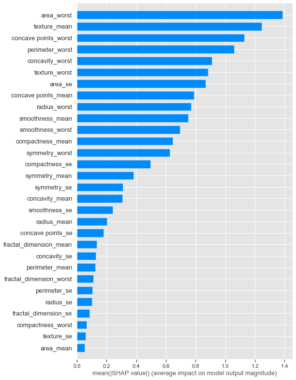

```python
max_display = 30
shap.summary_plot(shap_values, df_Xtest, plot_type="bar",
                  max_display = max_display)
```

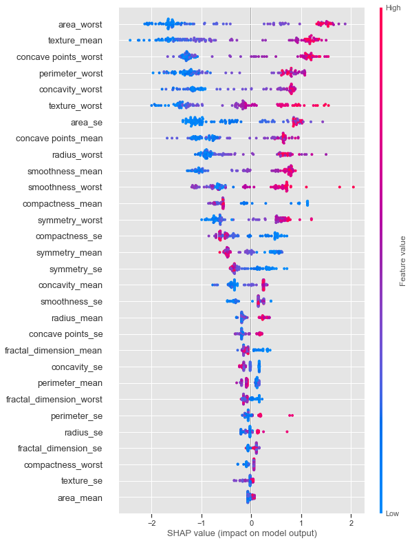

```python
shap.summary_plot(shap_values, df_Xtest, plot_type='dot', max_display = max_display)
```

# Time taken

```python
notebook_end_time = time.time()
time_taken = time.time() - notebook_start_time
h,m = divmod(time_taken,60*60)
print('Time taken to run whole noteook: {:.0f} hr {:.0f} min {:.0f} secs'.format(h, *divmod(m,60)))
```

```
Time taken to run whole noteook: 0 hr 0 min 19 secs
```